### Quantified Self Movement-Predict dumbell exersise goodness

*cperati, February 2016*

#### Executive Summary

The quantified self movement use a number of devices that quantify the performance of different activities. The dataset consists of measures regarding the execution of dumbell, a weight lifting exercises, performed in 5 different ways. The goal of this project is to create a model to predict the manner which the exercise was performed. The dataset is available in the publication *“Wearable Computing: Accelerometers’ Data Classification of Body Postures and Movements”*, at http://groupware.les.inf.puc-rio.br/har.

#### 1. Exploration and preparation of data

##### Load the data

```r
trainURL<-'https://d396qusza40orc.cloudfront.net/predmachlearn/pml-training.csv'
testURL<-'https://d396qusza40orc.cloudfront.net/predmachlearn/pml-testing.csv'

download.file(trainURL,'train.csv')
download.file(testURL,'test.csv')

train<-read.csv('train.csv'); test<-read.csv('test.csv')

library(caret);library(randomForest);library(rpart)
dim(train);dim(test)
```

```
## [1] 19622   160
```

```
## [1]  20 160
```

##### Treating Missing Values

The dataset consists of 160 variables out of which 93 have no missing values. However 67 variables have 19216 missing values in 19622 observations. Since only 2% of these variables include values, the decision is to discard them.

```r
trainNAs<-as.data.frame(sapply(train, function(x) sum(is.na(x))))
names(trainNAs)<-c('NAS')
trainNotNAs <- row.names(subset(trainNAs, NAS != 0))
trainNAsRem <- names(train) %in% trainNotNAs
train0<-train[!trainNAsRem]
```

##### Discard variables with no signifigant value

There are two categories of variables that were removed. First, the seven variables at the beginning of the dataset have no prediction value, as well as all variables with almost zero variation.

```r
train0<-train0[,-(1:7)]
nzv0<-nearZeroVar(train0)
train0<-train0[,-nzv0]
```

##### Prepare Testing set

The alterations performed to the training set should also be applied to the testing set. That is to remove the same variables so the two sets are aligned. After all alterations the variables of the training and test sets are reduced to 53.

```r
test0<-test[!trainNAsRem]
test0<-test0[,-(1:7)]
test0<-test0[,-nzv0]
dim(train0);dim(test0)
```

```
## [1] 19622    53
```

```
## [1] 20 53
```

#### 2. Model Creation, Evaluation, and Selection

The desision is to explore different models by using only a sample of the dataset. With this approach we reduce the computation time without affecting the results, atleast to the point of evaluating the performace of different models.

##### Sample preparation

The sample data is a random selection of the finalised training data (train0), 1/5 of its size. This sample data will be further divited in a training and testing set for the model creation.

```r
set.seed(11543)
dpS<-createDataPartition(train0$classe,list = FALSE,p=0.2)
sample<-train0[dpS,];dim(sample)
```

```
## [1] 3927   53
```

```r
dpS2<-createDataPartition(sample$classe,list = FALSE,p=0.7)
trainS<-sample[dpS2,];testS<-sample[-dpS2,]
dim(trainS);dim(testS)
```

```
## [1] 2751   53
```

```
## [1] 1176   53
```

##### Model creation

Three tree based classification models are evaluated.  
1. A random forests model  
2. A generalised boosted regression model. gbm  
3. A recursive partitioning model. rpart

Random Forests

```r
modS1<-randomForest(classe ~.,data = trainS,importance = TRUE)
preS1<-predict(modS1,testS)
confusionMatrix(preS1,testS$classe)$overall
```

```
##       Accuracy          Kappa  AccuracyLower  AccuracyUpper   AccuracyNull
##      0.9617347      0.9515785      0.9491308      0.9719546      0.2840136
## AccuracyPValue  McnemarPValue
##      0.0000000            NaN
```

Generalised boosted regression model

```r
preS2<-predict(modS2,testS)
confusionMatrix(preS2,testS$classe)$overall
```

[output not shown]

```
##       Accuracy          Kappa  AccuracyLower  AccuracyUpper   AccuracyNull
##     0.93367347     0.91606049     0.91790986     0.94722200     0.28401361
## AccuracyPValue  McnemarPValue
##     0.00000000     0.01809681
```

Recursive partitioning

```r
modS3<-rpart(classe~.,data=trainS,method = 'class')
preS3<-predict(modS3,testS,type = 'class')
confusionMatrix(preS3,testS$classe)$overall
```

```
##       Accuracy          Kappa  AccuracyLower  AccuracyUpper   AccuracyNull
##   6.930272e-01   6.118638e-01   6.657816e-01   7.193037e-01   2.840136e-01
## AccuracyPValue  McnemarPValue
##  3.333324e-185   3.444253e-22
```

##### Model Evaluation and Selection

Among the 3 models, random forests performed better with a very high accuracy (0.96) and kappa statistic (0.95), probably due to the creation of a large number of bootstrapped trees. The generalised boosted model with a 5-fold cross validation perfomed slightly lower, whereas the recursive partitioning performance was fair. So, random forests is used to create the model for the finalised training data (train0).

#### 3. Final Model and Prediction

The approach followed to create the final model is to further partition the training data (train0) to a new training set (train1) and validation set (valid1). The model is trained with the train1 set, and then evaluated with the valid1 set before proceeding to the final prediction to the finalised test set (test0).

##### Final Model Creation and Validation

```r
set.seed(11543)
dp0 <- createDataPartition(train0$classe, p = 0.7, list=FALSE)
train1 <- train0[dp0,]
valid1 <- train0[-dp0,]
dim(train1);dim(valid1)
```

```
## [1] 13737    53
```

```
## [1] 5885   53
```

```r
mod1<-randomForest(classe ~.,data = train1,importance = TRUE)
pre1<-predict(mod1,valid1)
mod1;confusionMatrix(pre1,valid1$classe)
```

```
##
## Call:
##  randomForest(formula = classe ~ ., data = train1, importance = TRUE)
##                Type of random forest: classification
##                      Number of trees: 500
## No. of variables tried at each split: 7
##
##         OOB estimate of  error rate: 0.52%
## Confusion matrix:
##      A    B    C    D    E class.error
## A 3902    4    0    0    0 0.001024066
## B   13 2641    4    0    0 0.006395786
## C    1   17 2374    4    0 0.009181970
## D    0    0   20 2229    3 0.010213144
## E    0    0    2    3 2520 0.001980198
```

```
## Confusion Matrix and Statistics
##
##           Reference
## Prediction    A    B    C    D    E
##          A 1674    5    0    0    0
##          B    0 1133    3    0    0
##          C    0    1 1023    8    1
##          D    0    0    0  956    1
##          E    0    0    0    0 1080
##
## Overall Statistics
##
##                Accuracy : 0.9968
##                  95% CI : (0.995, 0.9981)
##     No Information Rate : 0.2845
##     P-Value [Acc > NIR] : < 2.2e-16
##
##                   Kappa : 0.9959
##  Mcnemar's Test P-Value : NA
##
## Statistics by Class:
##
##                      Class: A Class: B Class: C Class: D Class: E
## Sensitivity            1.0000   0.9947   0.9971   0.9917   0.9982
## Specificity            0.9988   0.9994   0.9979   0.9998   1.0000
## Pos Pred Value         0.9970   0.9974   0.9903   0.9990   1.0000
## Neg Pred Value         1.0000   0.9987   0.9994   0.9984   0.9996
## Prevalence             0.2845   0.1935   0.1743   0.1638   0.1839
## Detection Rate         0.2845   0.1925   0.1738   0.1624   0.1835
## Detection Prevalence   0.2853   0.1930   0.1755   0.1626   0.1835
## Balanced Accuracy      0.9994   0.9971   0.9975   0.9957   0.9991
```

##### Final Prediction

```
##
## Call:
##  randomForest(formula = classe ~ ., data = train1, importance = TRUE)
##                Type of random forest: classification
##                      Number of trees: 500
## No. of variables tried at each split: 7
##
##         OOB estimate of  error rate: 0.52%
## Confusion matrix:
##      A    B    C    D    E  class.error
## A 3903    3    0    0    0 0.0007680492
## B   11 2643    4    0    0 0.0056433409
## C    0   17 2376    3    0 0.0083472454
## D    0    0   24 2225    3 0.0119893428
## E    0    0    2    4 2519 0.0023762376
```

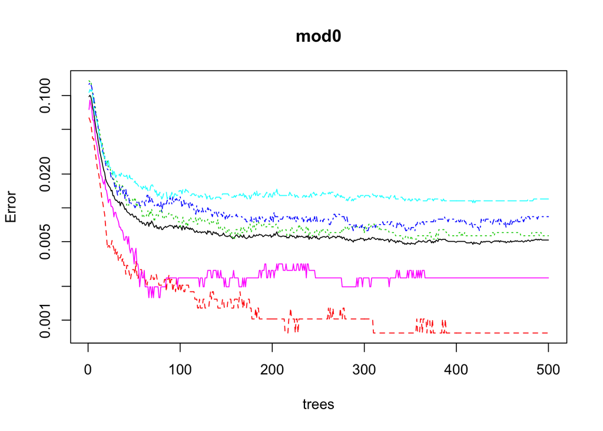

```
##  1  2  3  4  5  6  7  8  9 10 11 12 13 14 15 16 17 18 19 20
##  B  A  B  A  A  E  D  B  A  A  B  C  B  A  E  E  A  B  B  B
## Levels: A B C D E
```

```r
set.seed(11543)
mod0<-randomForest(classe ~.,data = train1,importance = TRUE)
pre0<-predict(mod0,test0);mod0;plot(mod0,log='y');pre0
```